# HW4

Dan Fanelli

July 5, 2016

# Outline:

- This data set has *HIGH CORRELATIONS* between dependent variables.
- Regular “Step” selection does is not having much of an impact (AUC stays the same before and after attribute selection).
- So calculate and rank all combinations of categorical variables by brute force. (after removing repeat highly correlated data)

# Load Data:

Converting the money character fields to numeric.

| INDEX | TARGET_FLAG | TARGET_AMT | KIDSDRIV | AGE | HOMEKIDS | YOJ | INCOME | PARENT1 | HOME_VAL | MSTATUS | SEX | EDUCATION | JOB | TRAVTIME | CAR_USE | BLUEBOOK | TIF | CAR_TYPE | RED_CAR | OLDCLAIM | CLM_FREQ | REVOKED | MVR_PTS | CAR_AGE | URBANICITY |
| --- | --- | --- | --- | --- | --- | --- | --- | --- | --- | --- | --- | --- | --- | --- | --- | --- | --- | --- | --- | --- | --- | --- | --- | --- | --- |
| 1 | 0 | 0 | 0 | 60 | 0 | 11 | 67349 | No | 0 | z_No | M | PhD | Professional | 14 | Private | 14230 | 11 | Minivan | yes | 4461 | 2 | No | 3 | 18 | Highly Urban/ Urban |
| 2 | 0 | 0 | 0 | 43 | 0 | 11 | 91449 | No | 257252 | z_No | M | z_High School | z_Blue Collar | 22 | Commercial | 14940 | 1 | Minivan | yes | 0 | 0 | No | 0 | 1 | Highly Urban/ Urban |
| 4 | 0 | 0 | 0 | 35 | 1 | 10 | 16039 | No | 124191 | Yes | z_F | z_High School | Clerical | 5 | Private | 4010 | 4 | z_SUV | no | 38690 | 2 | No | 3 | 10 | Highly Urban/ Urban |
| 5 | 0 | 0 | 0 | 51 | 0 | 14 | NA | No | 306251 | Yes | M | <High School | z_Blue Collar | 32 | Private | 15440 | 7 | Minivan | yes | 0 | 0 | No | 0 | 6 | Highly Urban/ Urban |
| 6 | 0 | 0 | 0 | 50 | 0 | NA | 114986 | No | 243925 | Yes | z_F | PhD | Doctor | 36 | Private | 18000 | 1 | z_SUV | no | 19217 | 2 | Yes | 3 | 17 | Highly Urban/ Urban |

### Plot and fill in the Nulls.

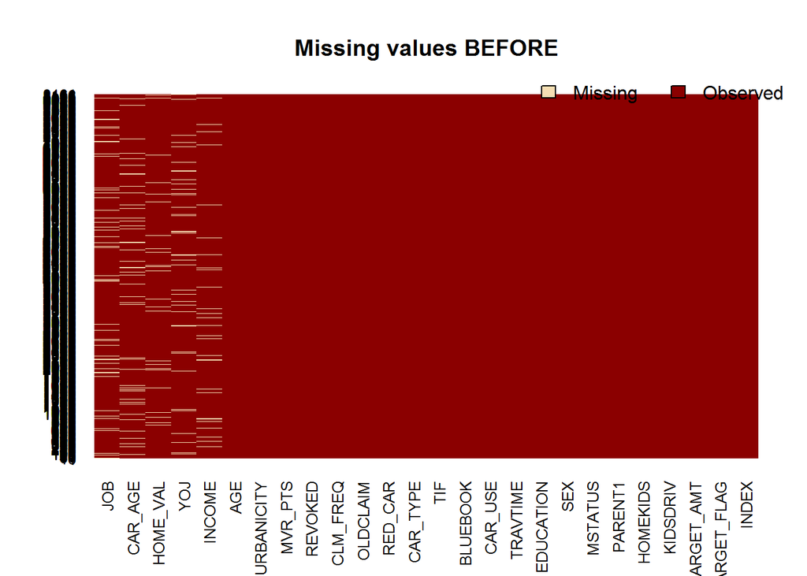

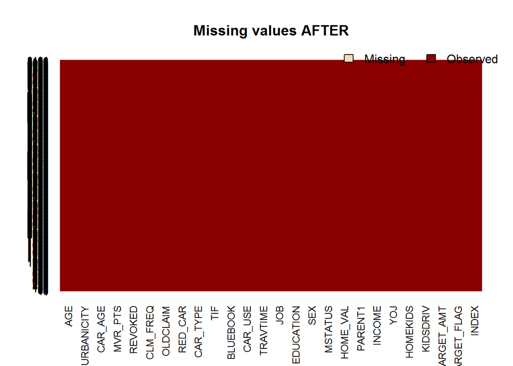

# Data Exploration

The cor plot shows *VERY LITTLE CORRELATION* between TARGET_FLAG/AMT and other fields (a “Weak” model?):

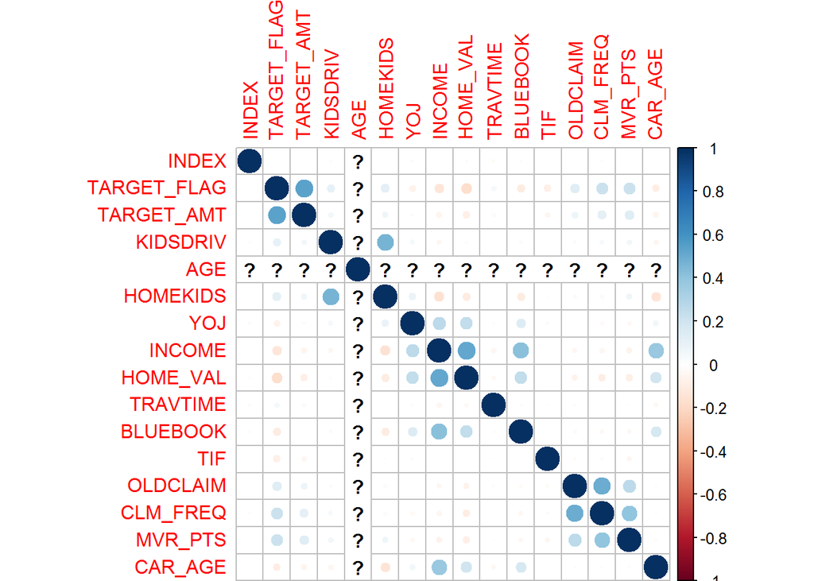

# Work:

Build multiple linear regression and binary logistic regression models to: * predict the probability that a person will crash their car and also * the amount of money it will cost if the person does crash their car

TARGET_FLAG: Was Car in a crash? 1=YES 0=NO

```r
cutoff <- nrow(ins)*.75
ins.train <- ins[1:cutoff,]
ins.test <- ins[(cutoff+1):nrow(ins),]
```

## Calculate the prediction ACCURACY based on JUST the Categorical Variables:

| col_names | accuracy |
| --- | --- |
| CAR_TYPE | 0.7331699 |
| CAR_USE | 0.7331699 |
| EDUCATION | 0.7331699 |
| JOB | 0.7331699 |
| MSTATUS | 0.7331699 |
| PARENT1 | 0.7331699 |
| RED_CAR | 0.7331699 |
| REVOKED | 0.7331699 |
| SEX | 0.7331699 |
| URBANICITY | 0.7331699 |

## Those categorical variables have the exact same calculated accuracties.

Could this be coincidence? Seems those columns are duplicates, run Chi-Square correlation tests to confirm:

| all_chi_sq_labels | all_chi_sq_results |
| --- | --- |
| car_type_to_car_use | 0.000 |
| car_type_to_education | 0.000 |
| car_type_to_job | 0.000 |
| car_type_to_mstatus | 0.315 |
| car_type_to_parent1 | 0.000 |
| car_type_to_red_car | 0.000 |
| car_type_to_revoked | 0.035 |
| car_type_to_sex | 0.000 |
| car_type_to_urbancity | 0.000 |

## Chi-Squared says some columns are exact duplicates: Remove Them! (We’ll keep CARTYPE):

```r
drops <- c("CAR_USE","EDUCATION","JOB","PARENT1","RED_CAR","SEX","URBANICITY")
ins.train <- ins.train[ , !(names(ins.train) %in% drops)]
ins.test <- ins.test[ , !(names(ins.test) %in% drops)]
```

```r
mstatus_to_revoked <- chisq.test(table(ins.train$MSTATUS, ins.train$REVOKED))
round(mstatus_to_revoked$p.value, digits = 3)
```

```
## [1] 0.001
```

So those are ALSO *DUPLICATES*, remove REVOKED

```r
drops <- c("REVOKED")
ins.train <- ins.train[ , !(names(ins.train) %in% drops)]
ins.test <- ins.test[ , !(names(ins.test) %in% drops)]
```

## Look at the data after those drops:

```r
kable(head(ins.train))
```

| INDEX | TARGET_FLAG | TARGET_AMT | KIDSDRIV | AGE | HOMEKIDS | YOJ | INCOME | HOME_VAL | MSTATUS | TRAVTIME | BLUEBOOK | TIF | CAR_TYPE | OLDCLAIM | CLM_FREQ | MVR_PTS | CAR_AGE |
| --- | --- | --- | --- | --- | --- | --- | --- | --- | --- | --- | --- | --- | --- | --- | --- | --- | --- |
| 1 | 0 | 0 | 0 | 60 | 0 | 11 | 67349 | 0 | z_No | 14 | 14230 | 11 | Minivan | 4461 | 2 | 3 | 18 |
| 2 | 0 | 0 | 0 | 43 | 0 | 11 | 91449 | 257252 | z_No | 22 | 14940 | 1 | Minivan | 0 | 0 | 0 | 1 |
| 4 | 0 | 0 | 0 | 35 | 1 | 10 | 16039 | 124191 | Yes | 5 | 4010 | 4 | z_SUV | 38690 | 2 | 3 | 10 |
| 5 | 0 | 0 | 0 | 51 | 0 | 14 | 137357 | 306251 | Yes | 32 | 15440 | 7 | Minivan | 0 | 0 | 0 | 6 |
| 6 | 0 | 0 | 0 | 50 | 0 | 14 | 114986 | 243925 | Yes | 36 | 18000 | 1 | z_SUV | 19217 | 2 | 3 | 17 |
| 7 | 1 | 2946 | 0 | 34 | 1 | 12 | 125301 | 0 | z_No | 46 | 17430 | 1 | Sports Car | 0 | 0 | 0 | 7 |

## Now, try some basic Step Selection:

```
## ACCURACY (BEFORE STEPS):
```

```
## [1] 0.7568627
```

```
## ACCURACY (AFTER STEPS):
```

```
## [1] 0.7583333
```

```
## AUC (BEFORE STEPS):
```

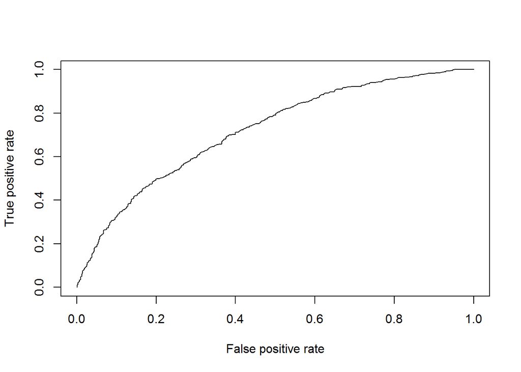

```
## [1] 0.7189499
```

```
## AUC (AFTER STEPS):
```

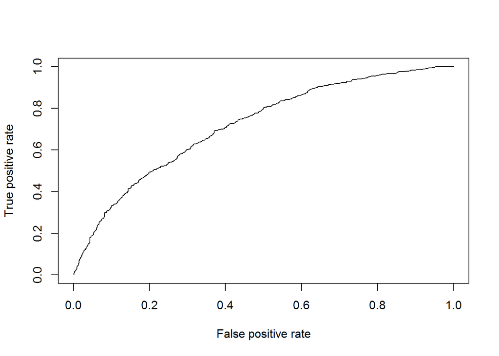

```
## [1] 0.7186488
```

# The Point: Step Selection (STILL) not giving much of an improvement.

So what can we do when no columns are showing real strength above the others?

# Grind out all combinations with some Tools: MuMIn DREDGE

```r
library(MuMIn)
core.glm <- glm(TARGET_FLAG ~  . -TARGET_AMT, data = ins.train)
options(na.action = "na.fail")
#dredge.result <- dredge(core.glm, rank="AIC", extra=c("R^2", "adjR^2"))
dredge.result <- dredge(core.glm, extra=c("R^2", "adjR^2"))
kable(head(dredge.result, n=20))
```

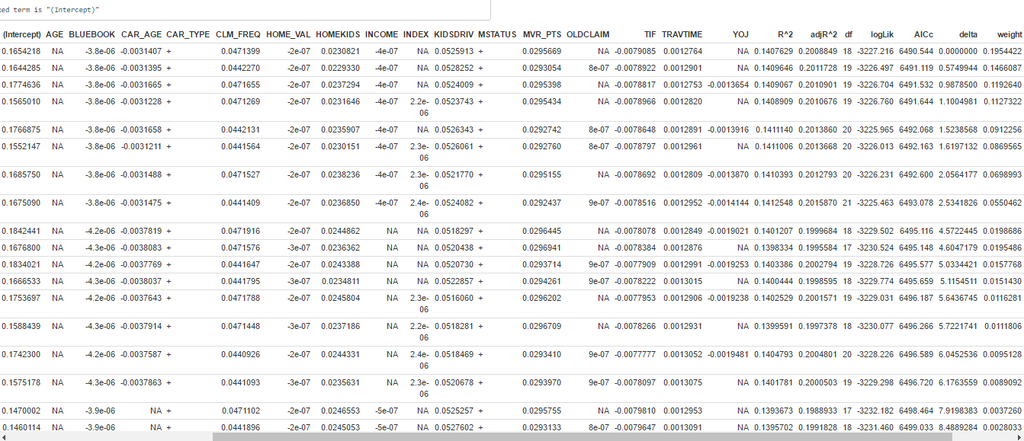